# Testing and deaths in Brazil

2020-06-10

6/24/2020

```r
cat('Date-time: ', Sys.time())
Date-time:  1595942152
## Load libraries
library(covid19)
library(ggplot2)
library(lubridate)
library(dplyr)
library(readr)
library(gsheet)
options(scipen = '999')
ggplot2::theme_set(theme_bw())
```

```r
# Read in our world in data
library(covid19)
owid <- covid19::owid
# filter for just Brazil
brazil <- owid %>% filter(location == 'Brazil')
# get the ivermectin vs non-ivermectin countries
owid$ivermectin <-
  ifelse(owid$location %in% c('Brazil', 'Peru', 'Dominican Republic', 'Honduras', 'Bolivia'),
         'Promoting ivermectin',
         ifelse(owid$location %in% c('Mexico', 'Canada', 'Chile',
                                     'Cuba', 'Argentina',
                                     'Nicaragua',
                                     'Colombia', 'Panama',
                                     'Uruguay', 'Venezuela'),
                'Not promoting ivermectin',
                NA))
iver <- owid %>% filter(!is.na(ivermectin))
```

# Reproduction of chart

## First attempt

There is a chart at https://twitter.com/sebasugarte/status/1275752348552437761/photo/1 showing the apparent effectiveness of ivermectin at reducing the % of deaths among cases. Using “Our World in Data” testing, cases, and deaths data, we reproduce it:

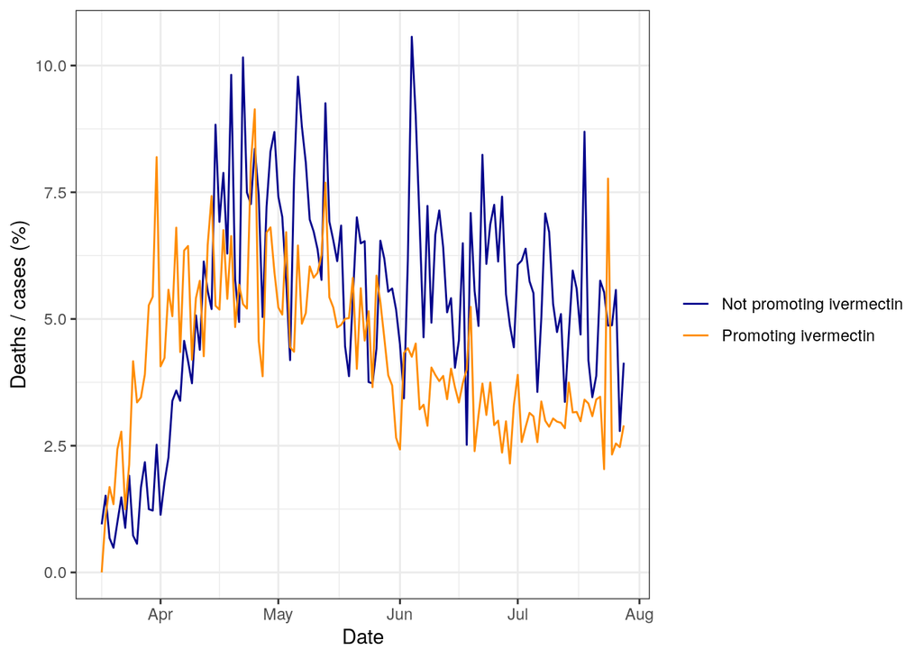

```r
pd <- iver %>%
  group_by(date, ivermectin) %>%
  summarise(deaths = sum(new_deaths),
            cases = sum(new_cases)) %>%
  ungroup %>%
  mutate(p = deaths / cases * 100)

ggplot(data = pd,
       aes(x = date,
           y = p,
           color = ivermectin)) +
  geom_line() +
  xlim(as.Date('2020-03-17'), as.Date(max(pd$date))) +
  labs(x = 'Date',
       y = 'Deaths / cases (%)') +
  scale_color_manual(name = '',
                     values = c('darkblue', 'darkorange'))
```

## With rolling

The above is far less “smooth” than the twitter chart, which suggests they used a rolling average. Let’s smooth via rolling 7 day average.

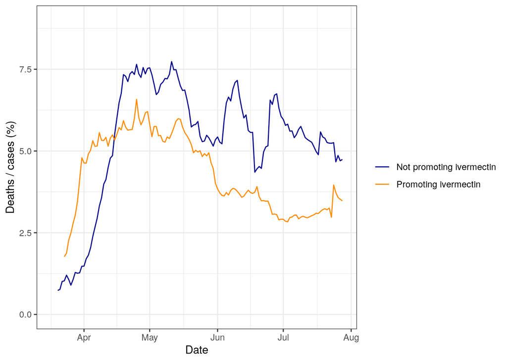

```r
pd <- iver %>%
  group_by(date, ivermectin) %>%
  summarise(deaths = sum(new_deaths),
            cases = sum(new_cases)) %>%
  ungroup %>%
  group_by(ivermectin) %>%
  mutate(deaths_roll = zoo::rollsumr(deaths, k = 7, fill = NA)) %>%
  mutate(cases_roll = zoo::rollsumr(cases, k = 7, fill = NA)) %>%
  mutate(p = deaths / cases * 100) %>%
  mutate(p_roll = deaths_roll / cases_roll * 100)

ggplot(data = pd,
       aes(x = date,
           y = p_roll,
           color = ivermectin)) +
  geom_line() +
  xlim(as.Date('2020-03-17'), as.Date(max(pd$date))) +
  labs(x = 'Date',
       y = 'Deaths / cases (%)') +
  scale_color_manual(name = '',
                     values = c('darkblue', 'darkorange')) +
  ylim(0, 9)
```

The above is similar, but not quite the same. It remains far less smooth than the twitter chart. Could it be that there rolling window is even larger than 7 days? Let’s try 15…

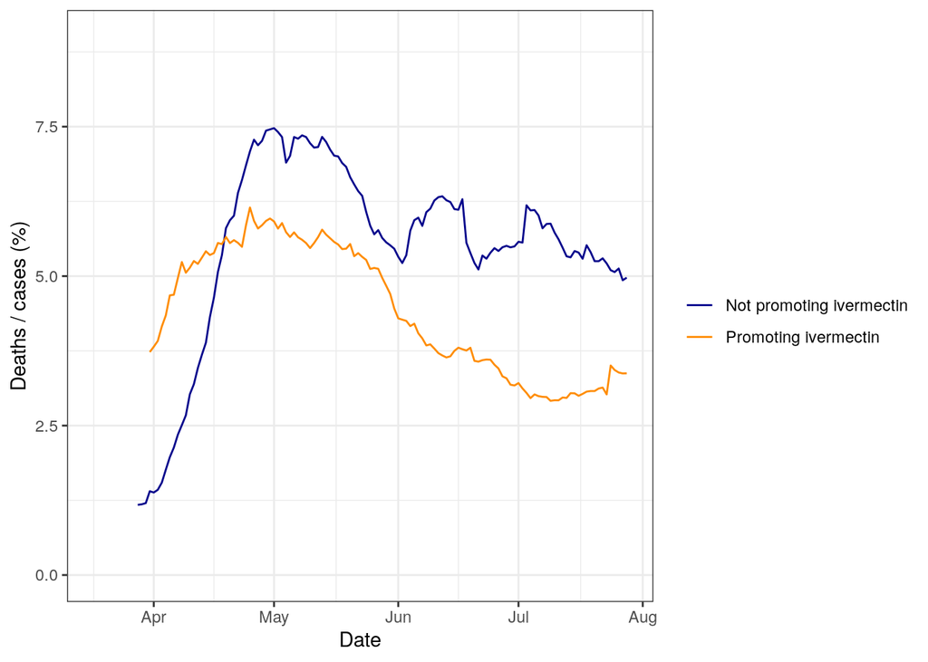

```r
pd <- iver %>%
  group_by(date, ivermectin) %>%
  summarise(deaths = sum(new_deaths),
            cases = sum(new_cases)) %>%
  ungroup %>%
  group_by(ivermectin) %>%
  mutate(deaths_roll = zoo::rollsumr(deaths, k = 15, fill = NA)) %>%
  mutate(cases_roll = zoo::rollsumr(cases, k = 15, fill = NA)) %>%
  mutate(p = deaths / cases * 100) %>%
  mutate(p_roll = deaths_roll / cases_roll * 100)

ggplot(data = pd,
       aes(x = date,
           y = p_roll,
           color = ivermectin)) +
  geom_line() +
  xlim(as.Date('2020-03-17'), as.Date(max(pd$date))) +
  labs(x = 'Date',
       y = 'Deaths / cases (%)') +
  scale_color_manual(name = '',
                     values = c('darkblue', 'darkorange')) +
  ylim(0, 9)
```

Same general idea, but not quite the same. The cross-over dates are different, the non-ivermectin humps are different. But this is similar enough for us to move forward with other question.

# Could this be attributable to outliers?

Let’s look at country-specific lines (instead of the aggregation) to see the extent to which things might be due to outliers.

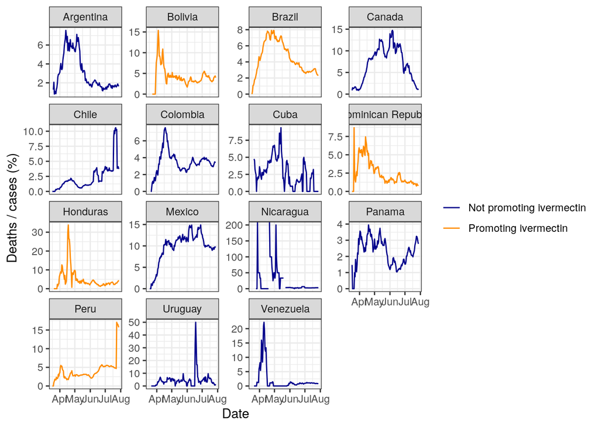

```r
pd <- iver %>%
  group_by(date, ivermectin, location) %>%
  summarise(deaths = sum(new_deaths),
            cases = sum(new_cases)) %>%
  ungroup %>%
  group_by(ivermectin, location) %>%
  mutate(deaths_roll = zoo::rollsumr(deaths, k = 7, fill = NA)) %>%
  mutate(cases_roll = zoo::rollsumr(cases, k = 7, fill = NA)) %>%
  mutate(p = deaths / cases * 100) %>%
  mutate(p_roll = deaths_roll / cases_roll * 100)

ggplot(data = pd,
       aes(x = date,
           y = p_roll,
           color = ivermectin,
           group = location)) +
  geom_line() +
  xlim(as.Date('2020-03-17'), as.Date(max(pd$date))) +
  labs(x = 'Date',
       y = 'Deaths / cases (%)') +
  scale_color_manual(name = '',
                     values = c('darkblue', 'darkorange')) +
  facet_wrap(~location, scales = 'free_y')
```

The above shows that country-specific variability is *very* high. There are ivermectin-promoting countries (Peru) and non-ivermectin promoting countries (Mexico) where the deaths over cases are on the rise. By the same token there are ivermectin-promoting countries (DR) and non-ivermectin promoting countries (Argentina) where the rate appears to be falling.

# What about testing

Testing, of course, plays an important role in the CFR (the more tests, the greater the denominator). So, let’s look at testing over time in each country

[figure not shown]

```r
pd <- iver %>%
  group_by(date, ivermectin, location) %>%
  summarise(deaths = sum(new_deaths),
            cases = sum(new_cases),
            tests = sum(new_tests_per_thousand)) %>%
  ungroup %>%
  group_by(ivermectin, location) %>%
  mutate(deaths_roll = zoo::rollsumr(deaths, k = 7, fill = NA)) %>%
  mutate(cases_roll = zoo::rollsumr(cases, k = 7, fill = NA)) %>%
  mutate(tests_roll = zoo::rollsumr(tests, k = 7, fill = NA)) %>%
  mutate(p = deaths / cases * 100) %>%
  mutate(p_roll = deaths_roll / cases_roll * 100)

ggplot(data = pd,
       aes(x = date,
           y = tests_roll,
           color = ivermectin,
           group = location)) +
  geom_line() +
  xlim(as.Date('2020-03-17'), as.Date(max(pd$date))) +
  labs(x = 'Date',
       y = 'Tests per thousand') +
  scale_color_manual(name = '',
                     values = c('darkblue', 'darkorange')) +
  facet_wrap(~location, scales = 'free_y')
```

# What about just deaths

Cases are biased by testing. And testing isn’t available. So, what options do we have for an unbiased comparison? Deaths per million population (instead of deaths per “cases”)? Let’s try.

[figure not shown]

```r
pd <- iver

ggplot(data = pd,
       aes(x = date,
           y = new_deaths_per_million,
           color = ivermectin,
           group = location)) +
  geom_point(size = 0.3, alpha = 0.5) +
  geom_smooth() +
  xlim(as.Date('2020-03-17'), as.Date(max(pd$date))) +
  labs(x = 'Date',
       y = 'New daily deaths per thousand') +
  scale_color_manual(name = '',
                     values = c('darkblue', 'darkorange')) +
  facet_wrap(~location, scales = 'free_y')
```

Okay, that’s cool, but hard to see trends. Let’s again aggregate across countries.

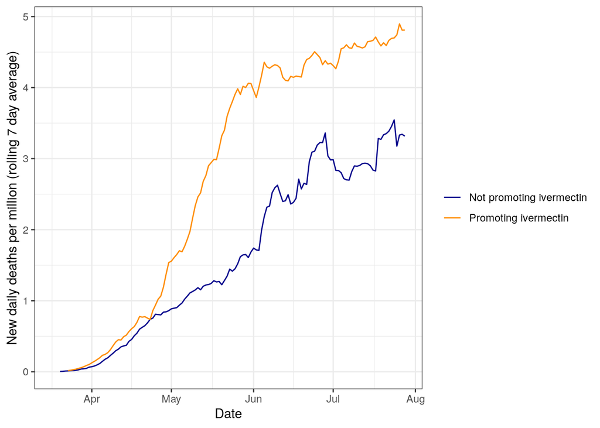

```r
pd <- iver %>% ungroup %>%
  filter(!location %in% 'Peru') %>%
  dplyr::arrange(date) %>%
  dplyr::group_by(date, ivermectin) %>%
  dplyr::summarise(deaths = sum(new_deaths),
            cases = sum(new_cases),
            population = sum(population)) %>%
  ungroup %>%
  group_by(ivermectin) %>%
  mutate(deaths_roll = zoo::rollmeanr(deaths, k = 7, fill = NA)) %>%
  ungroup %>%
  # mutate(population = mean(population)) %>%
  mutate(p = deaths / population * 1000000) %>%
  mutate(p_roll = deaths_roll / population * 1000000)

ggplot(data = pd,
       aes(x = date,
           y = p_roll,
           color = ivermectin)) +
  geom_line() +
  xlim(as.Date('2020-03-17'), as.Date(max(pd$date))) +
  labs(x = 'Date',
       y = 'New daily deaths per million (rolling 7 day average)') +
  scale_color_manual(name = '',
                     values = c('darkblue', 'darkorange'))
```

In the above, ivermectin no longer looks so good. But what’s the causal pathway? Could it be that a bad pandemic situation causes ivermectin use?

# Brazil vs Mexico

### Population adjusted

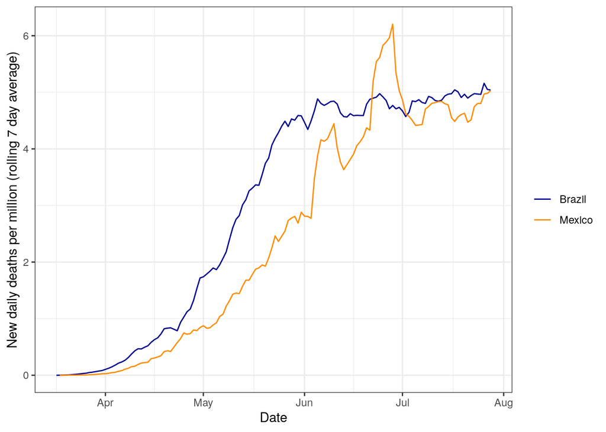

```r
pd <- iver %>% ungroup %>%
  filter(location %in% c('Mexico', 'Brazil')) %>%
  dplyr::arrange(date) %>%
  dplyr::group_by(date, location) %>%
  dplyr::summarise(deaths = sum(new_deaths),
            cases = sum(new_cases),
            population = sum(population)) %>%
  ungroup %>%
  group_by(location) %>%
  mutate(deaths_roll = zoo::rollmeanr(deaths, k = 7, fill = NA)) %>%
  ungroup %>%
  # mutate(population = mean(population)) %>%
  mutate(p = deaths / population * 1000000) %>%
  mutate(p_roll = deaths_roll / population * 1000000)

ggplot(data = pd,
       aes(x = date,
           y = p_roll,
           color = location)) +
  geom_line() +
  xlim(as.Date('2020-03-17'), as.Date(max(pd$date))) +
  labs(x = 'Date',
       y = 'New daily deaths per million (rolling 7 day average)') +
  scale_color_manual(name = '',
                     values = c('darkblue', 'darkorange'))
```

### Not population adjusted

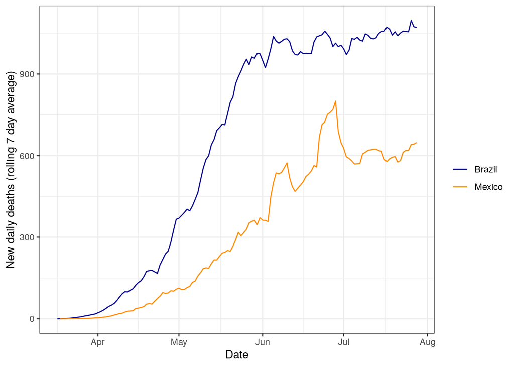

```r
pd <- iver %>% ungroup %>%
  filter(location %in% c('Mexico', 'Brazil')) %>%
  dplyr::arrange(date) %>%
  dplyr::group_by(date, location) %>%
  dplyr::summarise(deaths = sum(new_deaths),
            cases = sum(new_cases),
            population = sum(population)) %>%
  ungroup %>%
  group_by(location) %>%
  mutate(deaths_roll = zoo::rollmeanr(deaths, k = 7, fill = NA)) %>%
  ungroup %>%
  # mutate(population = mean(population)) %>%
  mutate(p = deaths / population * 1000000) %>%
  mutate(p_roll = deaths_roll / population * 1000000)

ggplot(data = pd,
       aes(x = date,
           y = deaths_roll,
           color = location)) +
  geom_line() +
  xlim(as.Date('2020-03-17'), as.Date(max(pd$date))) +
  labs(x = 'Date',
       y = 'New daily deaths (rolling 7 day average)') +
  scale_color_manual(name = '',
                     values = c('darkblue', 'darkorange'))
```

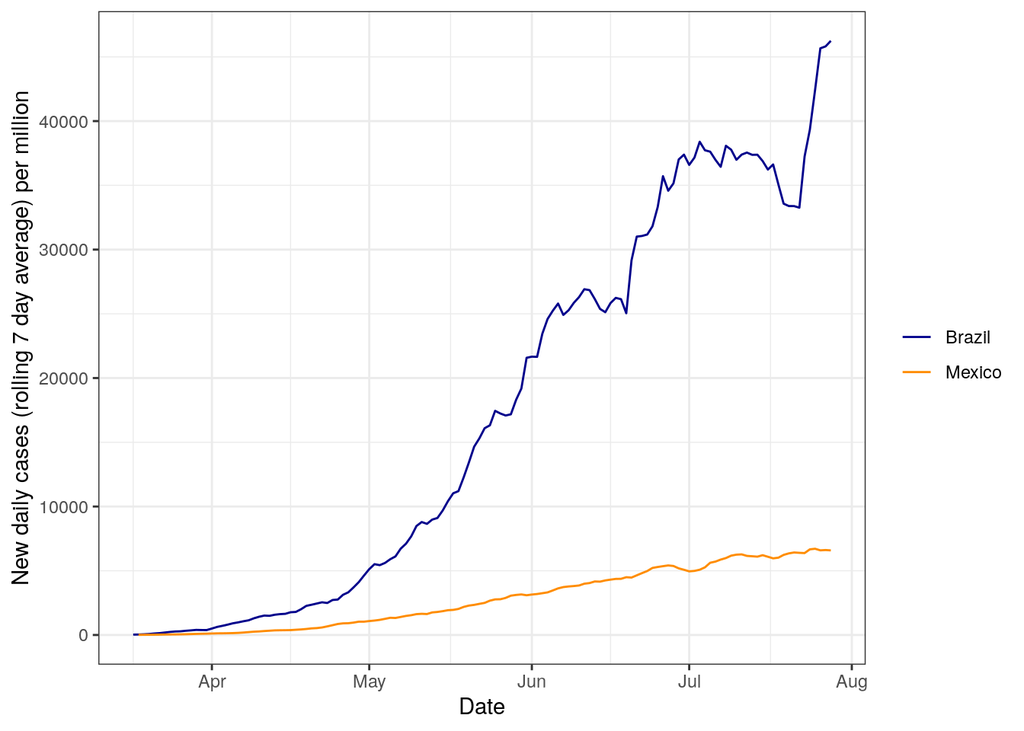

```r
pd <- iver %>% ungroup %>%
  filter(location %in% c('Mexico', 'Brazil')) %>%
  dplyr::arrange(date) %>%
  dplyr::group_by(date, location) %>%
  dplyr::summarise(deaths = sum(new_deaths),
            cases = sum(new_cases),
            population = sum(population)) %>%
  ungroup %>%
  group_by(location) %>%
  mutate(deaths_roll = zoo::rollmeanr(deaths, k = 7, fill = NA)) %>%
    mutate(cases_roll = zoo::rollmeanr(cases, k = 7, fill = NA)) %>%
  ungroup %>%
  # mutate(population = mean(population)) %>%
  mutate(p = cases / population * 1000000) %>%
  mutate(p_roll = cases_roll / population * 1000000)

ggplot(data = pd,
       aes(x = date,
           y = cases_roll,
           color = location)) +
  geom_line() +
  xlim(as.Date('2020-03-17'), as.Date(max(pd$date))) +
  labs(x = 'Date',
       y = 'New daily cases (rolling 7 day average) per million') +
  scale_color_manual(name = '',
                     values = c('darkblue', 'darkorange'))
```

### Cases (not population adjusted)

[figure not shown]

```r
pd <- iver %>% ungroup %>%
  filter(location %in% c('Mexico', 'Brazil')) %>%
  dplyr::arrange(date) %>%
  dplyr::group_by(date, location) %>%
  dplyr::summarise(deaths = sum(new_deaths),
            cases = sum(new_cases),
            population = sum(population)) %>%
  ungroup %>%
  group_by(location) %>%
  mutate(deaths_roll = zoo::rollmeanr(deaths, k = 7, fill = NA)) %>%
    mutate(cases_roll = zoo::rollmeanr(cases, k = 7, fill = NA)) %>%
  ungroup %>%
  # mutate(population = mean(population)) %>%
  mutate(p = cases / population * 1000000) %>%
  mutate(p_roll = cases_roll / population * 1000000)

ggplot(data = pd,
       aes(x = date,
           y = cases,
           color = location)) +
  geom_line() +
  xlim(as.Date('2020-03-17'), as.Date(max(pd$date))) +
  labs(x = 'Date',
       y = 'New daily cases (rolling 7 day average)') +
  scale_color_manual(name = '',
                     values = c('darkblue', 'darkorange'))
```

### Case fatality rate: Mexico vs Brazil

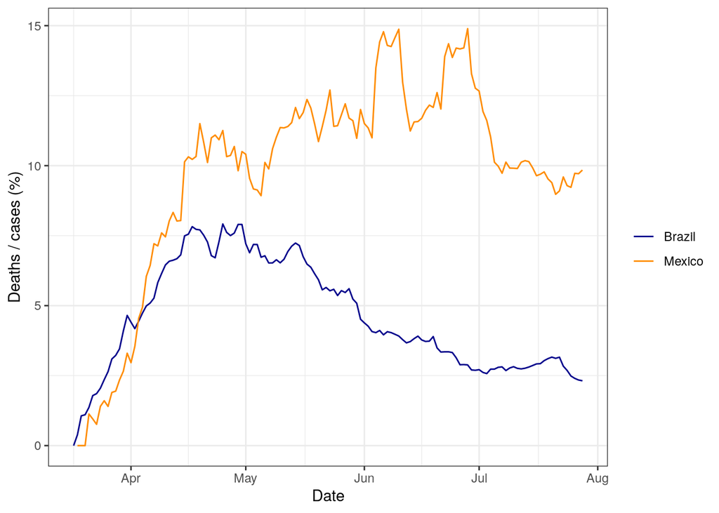

```r
pd <- iver %>%
    filter(location %in% c('Mexico', 'Brazil')) %>%
  group_by(date, location) %>%
  summarise(deaths = sum(new_deaths),
            cases = sum(new_cases)) %>%
  ungroup %>%
  group_by(location) %>%
  mutate(deaths_roll = zoo::rollsumr(deaths, k = 7, fill = NA)) %>%
  mutate(cases_roll = zoo::rollsumr(cases, k = 7, fill = NA)) %>%
  mutate(p = deaths / cases * 100) %>%
  mutate(p_roll = deaths_roll / cases_roll * 100)

ggplot(data = pd,
       aes(x = date,
           y = p_roll,
           color = location)) +
  geom_line() +
  xlim(as.Date('2020-03-17'), as.Date(max(pd$date))) +
  labs(x = 'Date',
       y = 'Deaths / cases (%)') +
  scale_color_manual(name = '',
                     values = c('darkblue', 'darkorange'))
```